# mmselva_7

Exercise 4:

```r
mod4=lm(Temp~Ozone, data=airquality)
res4 = residuals(mod4)
RSS4=sum(res4^2)
k=2
n=length(res4)

mod.ex=subset(airquality, Ozone!= "NA")

SSY4=deviance(lm(Temp~1, data=mod.ex))
SSY4.1=var(mod.ex$Temp)*115

adjR2= 1 - (RSS4/(n-k))/(SSY4.1/(n-1))
adjR2
```

```
## [1] 0.4832134
```

END EXERCISE 4

```r
data("airquality")
head(airquality, 15)
```

```
##    Ozone Solar.R Wind Temp Month Day
## 1     41     190  7.4   67     5   1
## 2     36     118  8.0   72     5   2
## 3     12     149 12.6   74     5   3
## 4     18     313 11.5   62     5   4
## 5     NA      NA 14.3   56     5   5
## 6     28      NA 14.9   66     5   6
## 7     23     299  8.6   65     5   7
## 8     19      99 13.8   59     5   8
## 9      8      19 20.1   61     5   9
## 10    NA     194  8.6   69     5  10
## 11     7      NA  6.9   74     5  11
## 12    16     256  9.7   69     5  12
## 13    11     290  9.2   66     5  13
## 14    14     274 10.9   68     5  14
## 15    18      65 13.2   58     5  15
```

```r
mod1=lm(Temp~Ozone, data=airquality)
summary(mod1)
```

```
##
## Call:
## lm(formula = Temp ~ Ozone, data = airquality)
##
## Residuals:
##     Min      1Q  Median      3Q     Max
## -22.147  -4.858   1.828   4.342  12.328
##
## Coefficients:
##             Estimate Std. Error t value Pr(>|t|)
## (Intercept) 69.41072    1.02971   67.41   <2e-16 ***
## Ozone        0.20081    0.01928   10.42   <2e-16 ***
## ---
## Signif. codes:  0 '***' 0.001 '**' 0.01 '*' 0.05 '.' 0.1 ' ' 1
##
## Residual standard error: 6.819 on 114 degrees of freedom
##   (37 observations deleted due to missingness)
## Multiple R-squared:  0.4877, Adjusted R-squared:  0.4832
## F-statistic: 108.5 on 1 and 114 DF,  p-value: < 2.2e-16
```

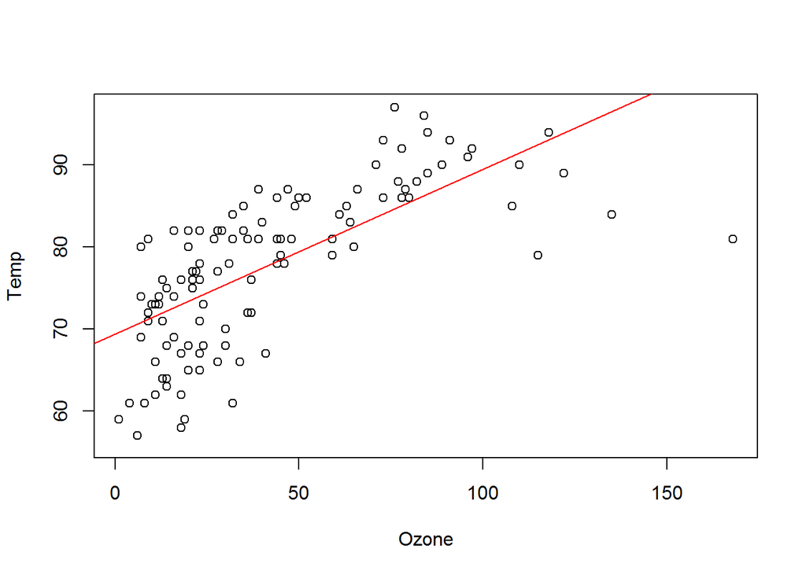

```r
plot(Temp~Ozone, data=airquality)
abline(lm(Temp~Ozone, data=airquality), col="red")
```

Exercise 5:

```r
library(lmtest)
dwtest(mod1, alternative=c("two.sided"))
```

```
##
##  Durbin-Watson test
##
## data:  mod1
## DW = 1.1833, p-value = 7.276e-06
## alternative hypothesis: true autocorrelation is not 0
```

When running this test for autocorrelation, a signficant result will allow us to reject the null hypothesis that there is no auto correlation. We do not want autocorrelation. Therefore, the fact that we get a significant p-value of 7.276e-06 means that there is auto correlation, and we should manipulate the data before fiting a linear model.

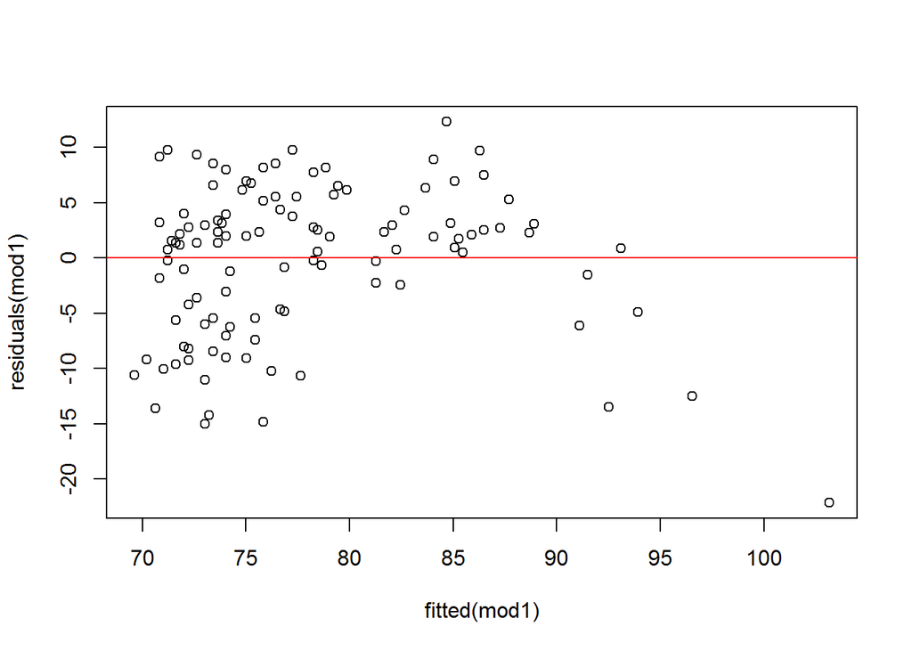

```r
plot(residuals(mod1)~fitted(mod1))
abline(lm(residuals(mod1)~fitted(mod1)), col="red")
```

```r
bptest(mod1)
```

```
##
##  studentized Breusch-Pagan test
##
## data:  mod1
## BP = 3.2346, df = 1, p-value = 0.0721
```

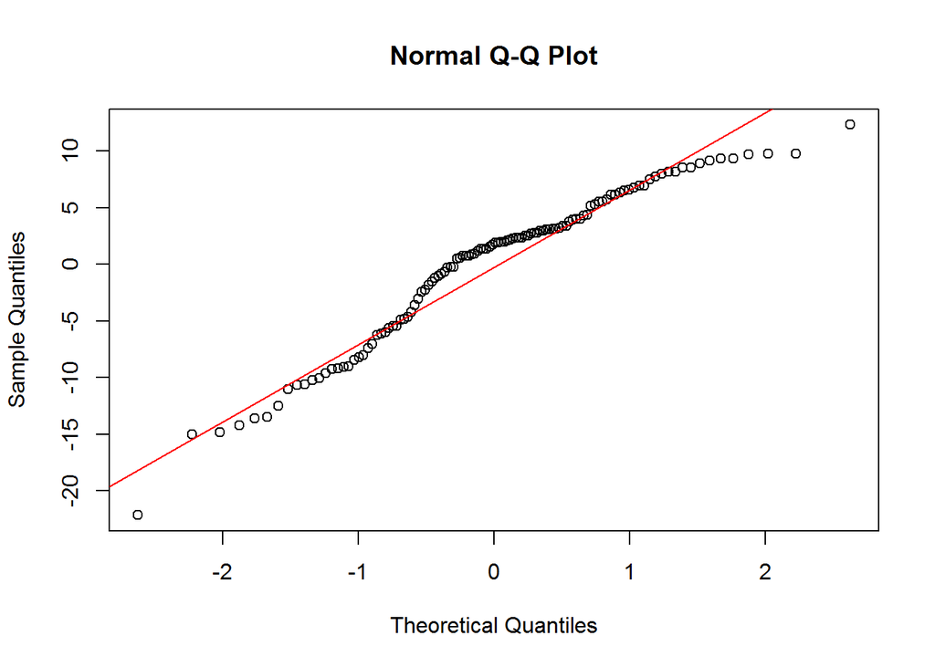

```r
qqnorm(residuals(mod1))
qqline(residuals(mod1), col="red")
```

```r
shapiro.test(residuals(mod1))
```

```
##
##  Shapiro-Wilk normality test
##
## data:  residuals(mod1)
## W = 0.94867, p-value = 0.000226
```

These test check for normality of the residuals. The qqnorm visually shows us that the residuals are not quite normal because they don’t follow the 1:1 line. The Shapiro-Wilk test further tells us with a significant p-value, that the residuals are not normally distributed.

END EXERCISE 5